# University Prestige and Source Credibility: Moderating Roles for Need for Cognition and Trust in Science and Scientists

- Show All Code
- Hide All Code
- View Source

PSY 120L Reproducible Analysis Report

Author

Peter Mirich

Published

June 7, 2026

## About This Report

This reproducible report documents the data preparation, variable construction, descriptive statistics, primary analyses, and figures for this study.

The report is intended to accompany a manuscript-style research paper. It is not the full paper itself. Instead, it shows how the reported analyses were produced from the dataset using a transparent and reproducible Quarto workflow.

## Study Overview

This study examined whether a university’s name influenced perceived credibility of the university’s research on a health topic, and whether credibility ratings differed by need for cognition (NFC), trust in science and scientists (TIS), and their interactions with university prestige.

Two 2 x 2 between-subjects factorial ANOVAs used university prestige as the manipulated independent variable in both analyses. Each ANOVA manipulated a different categorical moderator:

- Need for Cognition: high versus low
- Trust in Science and Scientists: high versus low.

The dependent variable was the perceived source credibility rating.

The primary analyses tested whether the main effect of university prestige and the particular moderators, NFC or TIS, and whether each moderator’s interaction with university prestige, predicted each source credibility outcome.

## Setup and Software Environment

This section loads the packages used for data preparation, scale construction, statistical modeling, estimated marginal means, and figures.

Load Packages

```r
library(tidyverse)  # data manipulation + plotting
library(psych)      # scale construction + reliability
library(afex)       # ANOVA models + effect sizes
library(emmeans)    # estimated marginal means + confidence intervals
```

## Data Source and Analysis Dataset

The dataset was imported from the project `data` folder. The imported dataset was saved as `study_raw` so that the original file remained unchanged throughout the report.

A smaller analysis dataset was then created for the current analyses. This dataset retained the study condition variables, demographic variables, perceived credibility items, need for cognition items, and trust in science and scientists items needed for variable preparation and analysis.

### Import Dataset

```r
study_raw <- read_csv("data/prestige_bias_data.csv")
```

### Check Imported Dataset

```r
dim(study_raw)
```

```
[1] 55 52
```

```r
names(study_raw)
```

```
 [1] "StartDate"             "EndDate"               "Duration (in seconds)"
 [4] "Finished"              "RecordedDate"          "Consent"
 [7] "MC1"                   "SCSIntelligent"        "SCSTrained"
[10] "SCSHonest"             "SCSTrust"              "SCSExpert"
[13] "SCSSelf"               "SCSHonorable"          "SCSInformed"
[16] "SCSMoral"              "SCSCompetent"          "SCSEthical"
[19] "SCSsensitive"          "SCSbright"             "SCSgenuine"
[22] "SCSunderstanding"      "NFC_1"                 "NFC_2"
[25] "NFC_3"                 "NFC_4"                 "NFC_5"
[28] "NFC_6"                 "TIS_1"                 "TIS_2"
[31] "TIS_3"                 "TIS_4"                 "TIS_5"
[34] "TIS_6"                 "TIS_7"                 "TIS_8"
[37] "TIS_9"                 "TIS_10"                "TIS_11"
[40] "TIS_12"                "TIS_13"                "TIS_14"
[43] "TIS_15"                "TIS_16"                "TIS_17"
[46] "TIS_18"                "TIS_19"                "TIS_20"
[49] "TIS_21"                "gender"                "age"
[52] "condition"
```

```r
head(study_raw)
```

```
# A tibble: 6 × 52
  StartDate   EndDate Duration (in seconds…¹ Finished RecordedDate Consent   MC1
  <chr>       <chr>                    <dbl>    <dbl> <chr>          <dbl> <dbl>
1 4/30/26 18… 4/30/2…                     56        1 4/30/26 18:…       2    NA
2 4/30/26 18… 4/30/2…                     43        1 4/30/26 18:…       2    NA
3 4/30/26 18… 4/30/2…                    137        1 4/30/26 18:…       2    NA
4 5/5/26 21:… 5/5/26…                    374        1 5/5/26 21:53       2     0
5 5/6/26 13:… 5/6/26…                    536        1 5/6/26 13:16       2    NA
6 5/6/26 18:… 5/6/26…                    385        1 5/6/26 18:23       2    NA
# ℹ abbreviated name: ¹`Duration (in seconds)`
# ℹ 45 more variables: SCSIntelligent <dbl>, SCSTrained <dbl>, SCSHonest <dbl>,
#   SCSTrust <dbl>, SCSExpert <dbl>, SCSSelf <dbl>, SCSHonorable <dbl>,
#   SCSInformed <dbl>, SCSMoral <dbl>, SCSCompetent <dbl>, SCSEthical <dbl>,
#   SCSsensitive <dbl>, SCSbright <dbl>, SCSgenuine <dbl>,
#   SCSunderstanding <dbl>, NFC_1 <dbl>, NFC_2 <dbl>, NFC_3 <dbl>, NFC_4 <dbl>,
#   NFC_5 <dbl>, NFC_6 <dbl>, TIS_1 <dbl>, TIS_2 <dbl>, TIS_3 <dbl>, …
```

The import checks confirm that the dataset loaded successfully, show the number of rows and columns, and display the variable names available in the original dataset.

### Create Analysis Dataset

```r
study_vars <- c(
  "condition", "age", "gender",

  "SCSIntelligent", "SCSTrained", "SCSHonest", "SCSTrust",
  "SCSExpert", "SCSSelf", "SCSHonorable", "SCSInformed",
  "SCSMoral", "SCSCompetent", "SCSEthical", "SCSsensitive",
  "SCSbright", "SCSgenuine", "SCSunderstanding",

  "NFC_1", "NFC_2", "NFC_3", "NFC_4", "NFC_5", "NFC_6",

  "TIS_1", "TIS_2", "TIS_3", "TIS_4", "TIS_5",
  "TIS_6", "TIS_7", "TIS_8", "TIS_9", "TIS_10",
  "TIS_11", "TIS_12", "TIS_13", "TIS_14", "TIS_15",
  "TIS_16", "TIS_17", "TIS_18", "TIS_19", "TIS_20",
  "TIS_21"
)

study_data <- study_raw %>%
  select(all_of(study_vars)) %>%
  mutate(
    across(everything(), as.numeric)
  )
```

### Check Analysis Dataset

```r
length(study_vars)
```

```
[1] 45
```

```r
dim(study_data)
```

```
[1] 55 45
```

```r
names(study_data)
```

```
 [1] "condition"        "age"              "gender"           "SCSIntelligent"
 [5] "SCSTrained"       "SCSHonest"        "SCSTrust"         "SCSExpert"
 [9] "SCSSelf"          "SCSHonorable"     "SCSInformed"      "SCSMoral"
[13] "SCSCompetent"     "SCSEthical"       "SCSsensitive"     "SCSbright"
[17] "SCSgenuine"       "SCSunderstanding" "NFC_1"            "NFC_2"
[21] "NFC_3"            "NFC_4"            "NFC_5"            "NFC_6"
[25] "TIS_1"            "TIS_2"            "TIS_3"            "TIS_4"
[29] "TIS_5"            "TIS_6"            "TIS_7"            "TIS_8"
[33] "TIS_9"            "TIS_10"           "TIS_11"           "TIS_12"
[37] "TIS_13"           "TIS_14"           "TIS_15"           "TIS_16"
[41] "TIS_17"           "TIS_18"           "TIS_19"           "TIS_20"
[45] "TIS_21"
```

The analysis dataset contains the variables required for the report. The checks confirm the number of selected variables, the dimensions of the analysis dataset, and the final variable names carried forward into the preparation and analysis sections.

## Variable Preparation

This section prepares the variables used in the primary analyses. The original imported dataset was left unchanged; all prepared variables were created in the working analysis dataset, `study_data`.

### Prepare Participant ID and Experimental Condition

```r
study_data <- study_data %>%
  mutate(
    id = row_number(),
    condition = factor(
      condition,
      levels = c(0, 1),
      labels = c("Low Prestige", "High Prestige")
    )
  )
```

The experimental condition variable was recoded as a labeled factor with two levels: High Prestige and Low Prestige. A participant ID variable was also created so that each row in the analysis dataset had a unique identifier.

### Check Experimental Condition Coding

```r
study_data %>%
  count(condition) %>%
  knitr::kable(
    col.names = c("Condition", "n")
  )
```

| Condition | n |
| --- | --- |
| Low Prestige | 28 |
| High Prestige | 27 |

The condition check confirms the number of participants assigned to each source prestige condition.

### Check Prepared Analysis Dataset

```r
dim(study_data)
```

```
[1] 55 46
```

```r
names(study_data)
```

```
 [1] "condition"        "age"              "gender"           "SCSIntelligent"
 [5] "SCSTrained"       "SCSHonest"        "SCSTrust"         "SCSExpert"
 [9] "SCSSelf"          "SCSHonorable"     "SCSInformed"      "SCSMoral"
[13] "SCSCompetent"     "SCSEthical"       "SCSsensitive"     "SCSbright"
[17] "SCSgenuine"       "SCSunderstanding" "NFC_1"            "NFC_2"
[21] "NFC_3"            "NFC_4"            "NFC_5"            "NFC_6"
[25] "TIS_1"            "TIS_2"            "TIS_3"            "TIS_4"
[29] "TIS_5"            "TIS_6"            "TIS_7"            "TIS_8"
[33] "TIS_9"            "TIS_10"           "TIS_11"           "TIS_12"
[37] "TIS_13"           "TIS_14"           "TIS_15"           "TIS_16"
[41] "TIS_17"           "TIS_18"           "TIS_19"           "TIS_20"
[45] "TIS_21"           "id"
```

The prepared analysis dataset contains the variables needed for scale construction, descriptive statistics, and primary analyses.

### Reverse-Code Scale Items

Items requiring reverse coding were transformed before scale scores were computed. For perceived source credibility, because the items used a 1–7 response scale, reverse-coded items were created by subtracting each original item response from 8. For need for cognition and for trust in science or scientists, because the items used a 1-5 response scale, reverse-coded items were created by subtracting each original item response from 6.

```r
study_data <- study_data %>%
  mutate(
    SCSIntelligent_R = 8 - SCSIntelligent,
    SCSHonest_R = 8 - SCSHonest,
    SCSHonorable_R = 8 - SCSHonorable,
    SCSInformed_R = 8 - SCSInformed,
    SCSMoral_R = 8 - SCSMoral,
    SCSbright_R = 8 - SCSbright,

    NFC_3_R = 6 - NFC_3,
    NFC_4_R = 6 - NFC_4,

    TIS_1_R = 6 - TIS_1,
    TIS_2_R = 6 - TIS_2,
    TIS_3_R = 6 - TIS_3,
    TIS_4_R = 6 - TIS_4,
    TIS_6_R = 6 - TIS_6,
    TIS_8_R = 6 - TIS_8,
    TIS_13_R = 6 - TIS_13,
    TIS_17_R = 6 - TIS_17,
    TIS_18_R = 6 - TIS_18,
    TIS_19_R = 6 - TIS_19,
    TIS_20_R = 6 - TIS_20,
    TIS_21_R = 6 - TIS_21
  )
```

### Check Reverse Coding

```r
study_data %>%
  select(
    SCSIntelligent, SCSIntelligent_R,
    NFC_3, NFC_3_R,
    TIS_1, TIS_1_R
  ) %>%
  head(10) %>%
  knitr::kable()
```

| SCSIntelligent | SCSIntelligent_R | NFC_3 | NFC_3_R | TIS_1 | TIS_1_R |
| --- | --- | --- | --- | --- | --- |
| 1 | 7 | 5 | 1 | 3 | 3 |
| 4 | 4 | 5 | 1 | 3 | 3 |
| 4 | 4 | 1 | 5 | 3 | 3 |
| 4 | 4 | 2 | 4 | 4 | 2 |
| 4 | 4 | 2 | 4 | 2 | 4 |
| 2 | 6 | 1 | 5 | 2 | 4 |
| 5 | 3 | 4 | 2 | 4 | 2 |
| 5 | 3 | 3 | 3 | 2 | 4 |
| 5 | 3 | 3 | 3 | 4 | 2 |
| 2 | 6 | 2 | 4 | 3 | 3 |

The reverse-coding check shows examples of original and reverse-coded item pairs. These checks confirm that reverse-coded variables were created before scale scores were computed.

### Create Scale Scores

Scale item lists were defined and used to compute perceived source credibility, need for cognition, and trust in science scores.

```r
# Define Source Credibility Scale items: total score
source_total_items <- c(
"SCSIntelligent_R", "SCSTrained", "SCSExpert",
  "SCSInformed_R", "SCSCompetent", "SCSbright_R","SCSSelf", "SCSsensitive", "SCSunderstanding","SCSHonest_R", "SCSTrust", "SCSHonorable_R",
  "SCSMoral_R", "SCSgenuine"
)

# Define Source Credibility Scale items: competence subscale
source_competence_items <- c(
  "SCSIntelligent_R", "SCSTrained", "SCSExpert",
  "SCSInformed_R", "SCSCompetent", "SCSbright_R"
)

# Define Source Credibility Scale items: caring/goodwill subscale
source_goodwill_items <- c(
  "SCSSelf", "SCSsensitive", "SCSunderstanding"
)

# Define Source Credibility Scale items: trustworthiness subscale
source_trustworthiness_items <- c(
  "SCSHonest_R", "SCSTrust", "SCSHonorable_R",
  "SCSMoral_R", "SCSgenuine"
)

# Define Need for Cognition Scale items
nfc_items <- c(
  "NFC_1", "NFC_2", "NFC_3_R",
  "NFC_4_R", "NFC_5", "NFC_6"
)

# Define Trust in Science Scale items
tis_items <- c(
  "TIS_1_R", "TIS_2_R", "TIS_3_R", "TIS_4_R",
  "TIS_5", "TIS_6_R", "TIS_7", "TIS_8_R",
  "TIS_9", "TIS_10", "TIS_11", "TIS_12",
  "TIS_13_R", "TIS_14", "TIS_15", "TIS_16",
  "TIS_17_R", "TIS_18_R", "TIS_19_R",
  "TIS_20_R", "TIS_21_R"
)

# Create scale scores
study_data <- study_data %>%
  mutate(
    source_total_scale = rowMeans(across(all_of(source_total_items)),na.rm = TRUE),
    source_competence_scale = rowMeans(across(all_of(source_competence_items)), na.rm = TRUE),
    source_goodwill_scale = rowMeans(across(all_of(source_goodwill_items)), na.rm = TRUE),
    source_trustworthiness_scale = rowMeans(across(all_of(source_trustworthiness_items)), na.rm = TRUE),
    nfc_scale = rowMeans(across(all_of(nfc_items)), na.rm = TRUE),
    tis_scale = rowMeans(across(all_of(tis_items)), na.rm = TRUE)
  )
```

### Check Scale Scores

```r
study_data %>%
  select(
    source_total_scale,

    source_competence_scale,
    source_goodwill_scale,
    source_trustworthiness_scale,
    nfc_scale,
    tis_scale
  ) %>%
  summary()
```

```
 source_total_scale source_competence_scale source_goodwill_scale
 Min.   :3.000      Min.   :2.500           Min.   :1.667
 1st Qu.:4.000      1st Qu.:4.000           1st Qu.:4.000
 Median :4.286      Median :4.167           Median :4.000
 Mean   :4.425      Mean   :4.439           Mean   :4.442
 3rd Qu.:5.000      3rd Qu.:5.000           3rd Qu.:5.000
 Max.   :6.786      Max.   :7.000           Max.   :6.667
 source_trustworthiness_scale   nfc_scale       tis_scale
 Min.   :3.000                Min.   :1.333   Min.   :1.333
 1st Qu.:3.900                1st Qu.:2.667   1st Qu.:3.167
 Median :4.200                Median :3.167   Median :3.571
 Mean   :4.396                Mean   :3.176   Mean   :3.561
 3rd Qu.:5.000                3rd Qu.:3.667   3rd Qu.:3.881
 Max.   :7.000                Max.   :4.667   Max.   :4.524
```

```r
study_data %>%
  summarise(
    source_total_scale_missing = mean(is.na(source_total_scale)),

    source_competence_scale_missing = mean(is.na(source_competence_scale)),
    source_goodwill_scale_missing = mean(is.na(source_goodwill_scale)),
    source_trustworthiness_scale_missing = mean(is.na(source_trustworthiness_scale)),
    nfc_scale_missing = mean(is.na(nfc_scale)),
    tis_scale_missing = mean(is.na(tis_scale))
  ) %>%
  knitr::kable()
```

| source_total_scale_missing | source_competence_scale_missing | source_goodwill_scale_missing | source_trustworthiness_scale_missing | nfc_scale_missing | tis_scale_missing |
| --- | --- | --- | --- | --- | --- |
| 0 | 0 | 0 | 0 | 0 | 0 |

The scale-score checks confirm that the computed scale scores fall within the expected response range and show whether any scale scores are missing.

### Create Median Splits

Low/high NFC and TIS grouping variables were created for the two planned 2 × 2 ANOVA models. Participants with scores at or below the sample medians were assigned to the Low level, and participants above the sample medians were assigned to the High level.

```r
# Compute median Need for Cognition score
nfc_median <- median(study_data$nfc_scale, na.rm = TRUE)

# Compute median Trust in Science score
tis_median <- median(study_data$tis_scale, na.rm = TRUE)

# Create low/high median split groups
study_data <- study_data %>%
  mutate(
    nfc_msplit = if_else(nfc_scale <= nfc_median, "Low", "High"),
    nfc_msplit = factor(nfc_msplit, levels = c("Low", "High")),

    tis_msplit = if_else(tis_scale <= tis_median, "Low", "High"),
    tis_msplit = factor(tis_msplit, levels = c("Low", "High"))
  )

# Print medians
nfc_median
```

```
[1] 3.166667
```

```r
tis_median
```

```
[1] 3.571429
```

```r
# Check group sizes
study_data %>%
  count(nfc_msplit) %>%
  knitr::kable()
```

| nfc_msplit | n |
| --- | --- |
| Low | 30 |
| High | 25 |

```r
study_data %>%
  count(tis_msplit) %>%
  knitr::kable()
```

| tis_msplit | n |
| --- | --- |
| Low | 28 |
| High | 27 |

Median splits created the need for cognition and trust in science moderators used in the primary analyses. The output reports the median values used for the splits and the number of participants assigned to each moderator group.

### Check Scale Reliability

Internal consistency was estimated for the source credibility, need for cognition, and trust in science scales before the scale scores were used in the primary analyses.

```r
# Create item-only data frames for each multi-item rating scale
source_total_item_df <- study_data %>%
  select(all_of(source_competence_items))

source_competence_item_df <- study_data %>%
  select(all_of(source_competence_items))

source_goodwill_item_df <- study_data %>%
  select(all_of(source_goodwill_items))

source_trustworthiness_item_df <- study_data %>%
  select(all_of(source_trustworthiness_items))

nfc_item_df <- study_data %>%
  select(all_of(nfc_items))

tis_item_df <- study_data %>%
  select(all_of(tis_items))

# Compute internal consistency estimates
source_total_alpha <- psych::alpha(source_total_item_df)
source_total_omega <- psych::omega(source_total_item_df, plot = FALSE)


source_competence_alpha <- psych::alpha(source_competence_item_df)
source_competence_omega <- psych::omega(source_competence_item_df, plot = FALSE)

source_goodwill_alpha <- psych::alpha(source_goodwill_item_df)
source_goodwill_omega <- psych::omega(source_goodwill_item_df, plot = FALSE)

source_trustworthiness_alpha <- psych::alpha(source_trustworthiness_item_df)
source_trustworthiness_omega <- psych::omega(source_trustworthiness_item_df, plot = FALSE)

nfc_alpha <- psych::alpha(nfc_item_df)
nfc_omega <- psych::omega(nfc_item_df, plot = FALSE)

tis_alpha <- psych::alpha(tis_item_df)
tis_omega <- psych::omega(tis_item_df, plot = FALSE)

# Print only alpha and omega coefficients
tibble(
  scale = c(
    "Source Credibility: Total",
    "Source Credibility: Competence",
    "Source Credibility: Caring/Goodwill",
    "Source Credibility: Trustworthiness",
    "Need for Cognition",
    "Trust in Science"
  ),
  alpha = c(
    source_total_alpha$total$raw_alpha,
    source_competence_alpha$total$raw_alpha,
    source_goodwill_alpha$total$raw_alpha,
    source_trustworthiness_alpha$total$raw_alpha,
    nfc_alpha$total$raw_alpha,
    tis_alpha$total$raw_alpha
  ),
  omega = c(
    source_total_omega$omega.tot,
    source_competence_omega$omega.tot,
    source_goodwill_omega$omega.tot,
    source_trustworthiness_omega$omega.tot,
    nfc_omega$omega.tot,
    tis_omega$omega.tot
  )
) %>%
  knitr::kable(digits = 2)
```

[output not shown]

## Descriptive Statistics

This section summarizes the scale scores and sample composition before the primary hypothesis tests.

### Scale Score Descriptives

```r
study_data %>%
  select(
    source_total_scale,
    source_competence_scale,
    source_goodwill_scale,
    source_trustworthiness_scale,
    nfc_scale,
    tis_scale
  ) %>%
  psych::describe() %>%
  knitr::kable(digits = 2)
```

|  | vars | n | mean | sd | median | trimmed | mad | min | max | range | skew | kurtosis | se |
| --- | --- | --- | --- | --- | --- | --- | --- | --- | --- | --- | --- | --- | --- |
| source_total_scale | 1 | 55 | 4.42 | 0.72 | 4.29 | 4.41 | 0.64 | 3.00 | 6.79 | 3.79 | 0.57 | 0.51 | 0.10 |
| source_competence_scale | 2 | 55 | 4.44 | 0.88 | 4.17 | 4.44 | 0.74 | 2.50 | 7.00 | 4.50 | 0.30 | 0.05 | 0.12 |
| source_goodwill_scale | 3 | 55 | 4.44 | 0.88 | 4.00 | 4.41 | 0.49 | 1.67 | 6.67 | 5.00 | 0.16 | 0.91 | 0.12 |
| source_trustworthiness_scale | 4 | 55 | 4.40 | 0.81 | 4.20 | 4.35 | 0.89 | 3.00 | 7.00 | 4.00 | 0.74 | 0.40 | 0.11 |
| nfc_scale | 5 | 55 | 3.18 | 0.74 | 3.17 | 3.19 | 0.74 | 1.33 | 4.67 | 3.33 | -0.18 | -0.11 | 0.10 |
| tis_scale | 6 | 55 | 3.56 | 0.54 | 3.57 | 3.57 | 0.49 | 1.33 | 4.52 | 3.19 | -0.98 | 3.49 | 0.07 |

The table reports descriptive statistics for overall perceived source credibility, NFC, and TIS scale scores used in the primary analyses. Also reported are the three subscales (competence, goodwill, trustworthiness) of perceived source credibiity.

### Sample Composition by Age and Gender

```r
# Summarize age group
study_data %>%
  mutate(
    age_group = factor(
      age,
      levels = c(1, 2, 3, 4, 5, 6),
      labels = c(
        "Under 18",
        "18-24",
        "25-34",
        "35-44",
        "45-54",
        "55 or older"
      )
    )
  ) %>%
  count(age_group) %>%
  mutate(percent = round(100 * n / sum(n), 1)) %>%
  knitr::kable(
    col.names = c("Age Group", "n", "Percent"),
    caption = "Sample Composition by Age Group"
  )
```

Sample Composition by Age Group

| Age Group | n | Percent |
| --- | --- | --- |
| 18-24 | 45 | 81.8 |
| 25-34 | 4 | 7.3 |
| 35-44 | 1 | 1.8 |
| 45-54 | 1 | 1.8 |
| 55 or older | 4 | 7.3 |

```r
# Summarize gender
study_data %>%
  mutate(
    gender_group = factor(
      gender,
      levels = c(1, 2, 3, 4),
      labels = c(
        "Male",
        "Female",
        "Non-binary / Third gender",
        "Prefer not to say"
      )
    )
  ) %>%
  count(gender_group) %>%
  mutate(percent = round(100 * n / sum(n), 1)) %>%
  knitr::kable(
    col.names = c("Gender", "n", "Percent"),
    caption = "Sample Composition by Gender"
  )
```

Sample Composition by Gender

| Gender | n | Percent |
| --- | --- | --- |
| Male | 12 | 21.8 |
| Female | 40 | 72.7 |
| Prefer not to say | 3 | 5.5 |

These tables report the number and percentages of participants in each age group and gender category.

## Correlations Among the Variables

The matrix below shows correlations among source credibility measures (including measures for its three subscales, and the NFC and TIS scales.

```r
# Correlations for the main continuous study variables
psych::corr.test(
  study_data %>%
    select(
      source_total_scale,
      source_competence_scale,
      source_goodwill_scale,
      source_trustworthiness_scale,
      nfc_scale,
      tis_scale
    )
)
```

```
Call:psych::corr.test(x = study_data %>% select(source_total_scale,
    source_competence_scale, source_goodwill_scale, source_trustworthiness_scale,
    nfc_scale, tis_scale))
Correlation matrix
                             source_total_scale source_competence_scale
source_total_scale                         1.00                    0.92
source_competence_scale                    0.92                    1.00
source_goodwill_scale                      0.62                    0.40
source_trustworthiness_scale               0.87                    0.71
nfc_scale                                  0.08                    0.04
tis_scale                                  0.28                    0.25
                             source_goodwill_scale source_trustworthiness_scale
source_total_scale                            0.62                         0.87
source_competence_scale                       0.40                         0.71
source_goodwill_scale                         1.00                         0.36
source_trustworthiness_scale                  0.36                         1.00
nfc_scale                                     0.05                         0.11
tis_scale                                     0.18                         0.25
                             nfc_scale tis_scale
source_total_scale                0.08      0.28
source_competence_scale           0.04      0.25
source_goodwill_scale             0.05      0.18
source_trustworthiness_scale      0.11      0.25
nfc_scale                         1.00      0.14
tis_scale                         0.14      1.00
Sample Size
[1] 55
Probability values (Entries above the diagonal are adjusted for multiple tests.)
                             source_total_scale source_competence_scale
source_total_scale                         0.00                    0.00
source_competence_scale                    0.00                    0.00
source_goodwill_scale                      0.00                    0.00
source_trustworthiness_scale               0.00                    0.00
nfc_scale                                  0.55                    0.75
tis_scale                                  0.04                    0.06
                             source_goodwill_scale source_trustworthiness_scale
source_total_scale                            0.00                         0.00
source_competence_scale                       0.03                         0.00
source_goodwill_scale                         0.00                         0.08
source_trustworthiness_scale                  0.01                         0.00
nfc_scale                                     0.71                         0.42
tis_scale                                     0.19                         0.07
                             nfc_scale tis_scale
source_total_scale                1.00      0.35
source_competence_scale           1.00      0.51
source_goodwill_scale             1.00      1.00
source_trustworthiness_scale      1.00      0.51
nfc_scale                         0.00      1.00
tis_scale                         0.31      0.00

 To see confidence intervals of the correlations, print with the short=FALSE option
```

## Primary Analyses

This section reports the primary analyses used to test whether university prestige and the moderators (NFC and TIS) predicted perceived credibility ratings of university research, and the interactions of each moderator with university prestige.

Two 2 x 2 ANOVAs were estimated. Both used perceived credibility of university research as the dependent variable. University prestige was the manipulated independent variable in each ANOVA. The first used NFC as the moderator; the second used TIS as the moderator.

### Model 1: Source Total Model with NFC

A 2 x 2 ANOVA tested whether ratings of perceived credibility of university research differed by university prestige, NFC, and university prestige x NFC interaction.

```r
#| label: anova_source_total_nfc
#| echo: true
#| warning: false
#| message: false

a1_total <- afex::aov_ez(
  id = "id",
  dv = "source_total_scale",
  between = c("condition", "nfc_msplit"),
  data = study_data
)

# Print the ANOVA table
a1_total
```

```
Anova Table (Type 3 tests)

Response: source_total_scale
                Effect    df  MSE    F   ges p.value
1            condition 1, 51 0.54 0.49  .009    .488
2           nfc_msplit 1, 51 0.54 0.00 <.001    .973
3 condition:nfc_msplit 1, 51 0.54 0.02 <.001    .881
---
Signif. codes:  0 '***' 0.001 '**' 0.01 '*' 0.05 '+' 0.1 ' ' 1
```

The ANOVA table reports the main effects of university prestige and NFC, and the university prestige x NFC interaction for perceived credibility ratings of research.

### Model 1: Estimated Means for Source Total with NFC

```r
#| label: estimated_means_source_total_nfc
#| echo: true
#| warning: false
#| message: false

emmeans(a1_total, ~ condition)
```

```
 condition     emmean    SE df lower.CL upper.CL
 Low Prestige    4.49 0.142 51     4.21     4.78
 High Prestige   4.36 0.141 51     4.07     4.64

Results are averaged over the levels of: nfc_msplit
Confidence level used: 0.95
```

```r
emmeans(a1_total, ~ nfc_msplit)
```

```
 nfc_msplit emmean    SE df lower.CL upper.CL
 Low          4.43 0.135 51     4.16     4.70
 High         4.42 0.148 51     4.13     4.72

Results are averaged over the levels of: condition
Confidence level used: 0.95
```

```r
emmeans(a1_total, ~ condition * nfc_msplit)
```

```
 condition     nfc_msplit emmean    SE df lower.CL upper.CL
 Low Prestige  Low          4.48 0.178 51     4.13     4.84
 High Prestige Low          4.37 0.203 51     3.97     4.78
 Low Prestige  High         4.51 0.221 51     4.06     4.95
 High Prestige High         4.34 0.196 51     3.94     4.73

Confidence level used: 0.95
```

The estimated means show the percieved credibility (null score pattern) across NFC, and the lack of university prestige and NFC interaction.

### Model 2: Source Competence with NFC

```r
a2_competence <- afex::aov_ez(
  id = "id",
  dv = "source_competence_scale",
  between = c("condition", "nfc_msplit"),
  data = study_data
)

# Print the ANOVA table
a2_competence
```

```
Anova Table (Type 3 tests)

Response: source_competence_scale
                Effect    df  MSE    F   ges p.value
1            condition 1, 51 0.82 0.39  .008    .533
2           nfc_msplit 1, 51 0.82 0.00 <.001    .986
3 condition:nfc_msplit 1, 51 0.82 0.12  .002    .733
---
Signif. codes:  0 '***' 0.001 '**' 0.01 '*' 0.05 '+' 0.1 ' ' 1
```

This ANOVA table reports the main effects of university prestige and NFC, and their interaction on ratings of source competence, a subscale of total source credibility.

### Model 2: Estimated Means for Source Competence with NFC

```r
emmeans(a2_competence, ~ condition)
```

```
 condition     emmean    SE df lower.CL upper.CL
 Low Prestige    4.52 0.175 51     4.17     4.87
 High Prestige   4.37 0.174 51     4.02     4.71

Results are averaged over the levels of: nfc_msplit
Confidence level used: 0.95
```

```r
emmeans(a2_competence, ~ nfc_msplit)
```

```
 nfc_msplit emmean    SE df lower.CL upper.CL
 Low          4.45 0.166 51     4.11     4.78
 High         4.44 0.182 51     4.08     4.81

Results are averaged over the levels of: condition
Confidence level used: 0.95
```

```r
emmeans(a2_competence, ~ condition * nfc_msplit)
```

```
 condition     nfc_msplit emmean    SE df lower.CL upper.CL
 Low Prestige  Low          4.48 0.219 51     4.04     4.92
 High Prestige Low          4.41 0.250 51     3.91     4.91
 Low Prestige  High         4.56 0.272 51     4.01     5.11
 High Prestige High         4.32 0.241 51     3.84     4.81

Confidence level used: 0.95
```

The estimated means show the percieved competence (null score pattern) across NFC, and the lack of university prestige and NFC interaction.

### Model 3: Source Goodwill Model with NFC

```r
# 2x2 between-subjects ANOVA predicting source goodwill scores
# DV: source_goodwill_scale
# Factors: condition and Need for Cognition group
a3_goodwill <- afex::aov_ez(
  id = "id",
  dv = "source_goodwill_scale",
  between = c("condition", "nfc_msplit"),
  data = study_data
)

# Print the ANOVA table
a3_goodwill
```

```
Anova Table (Type 3 tests)

Response: source_goodwill_scale
                Effect    df  MSE    F   ges p.value
1            condition 1, 51 0.79 0.01 <.001    .930
2           nfc_msplit 1, 51 0.79 0.53  .010    .471
3 condition:nfc_msplit 1, 51 0.79 0.81  .016    .372
---
Signif. codes:  0 '***' 0.001 '**' 0.01 '*' 0.05 '+' 0.1 ' ' 1
```

This ANOVA table reports the main effects of university prestige and NFC, and their interaction on ratings of source goodwill, a subscale of total source credibility.

### Model 3: Estimated Means for Source Goodwill with NFC

```r
emmeans(a3_goodwill, ~ condition)
```

```
 condition     emmean    SE df lower.CL upper.CL
 Low Prestige    4.41 0.172 51     4.06     4.76
 High Prestige   4.43 0.172 51     4.09     4.78

Results are averaged over the levels of: nfc_msplit
Confidence level used: 0.95
```

```r
emmeans(a3_goodwill, ~ nfc_msplit)
```

```
 nfc_msplit emmean    SE df lower.CL upper.CL
 Low          4.51 0.164 51     4.18     4.84
 High         4.33 0.180 51     3.97     4.69

Results are averaged over the levels of: condition
Confidence level used: 0.95
```

```r
emmeans(a3_goodwill, ~ condition * nfc_msplit)
```

```
 condition     nfc_msplit emmean    SE df lower.CL upper.CL
 Low Prestige  Low          4.61 0.216 51     4.17     5.04
 High Prestige Low          4.41 0.247 51     3.91     4.91
 Low Prestige  High         4.21 0.269 51     3.67     4.75
 High Prestige High         4.45 0.238 51     3.97     4.93

Confidence level used: 0.95
```

The estimated means show the percieved goodwill (null score pattern) across NFC, and the lack of university prestige and NFC interaction.

### Model 4: Source Trustworthiness Model with NFC

```r
# Between-subjects ANOVA predicting source trustworthiness scores
# DV: source_trustworthiness_scale
# Factors: condition and Need for Cognition group
a4_trustworthiness <- afex::aov_ez(
  id = "id",
  dv = "source_trustworthiness_scale",
  between = c("condition", "nfc_msplit"),
  data = study_data
)

# Print the ANOVA table
a4_trustworthiness
```

```
Anova Table (Type 3 tests)

Response: source_trustworthiness_scale
                Effect    df  MSE    F  ges p.value
1            condition 1, 51 0.67 0.95 .018    .335
2           nfc_msplit 1, 51 0.67 0.17 .003    .683
3 condition:nfc_msplit 1, 51 0.67 0.26 .005    .613
---
Signif. codes:  0 '***' 0.001 '**' 0.01 '*' 0.05 '+' 0.1 ' ' 1
```

This ANOVA table reports the main effects of university prestige and NFC, and their interaction on source trustworthiness, a subscale of total source credibility.

### Model 4: Estimated Means for Source Trustworthiness with NFC

```r
emmeans(a4_trustworthiness, ~ condition)
```

```
 condition     emmean    SE df lower.CL upper.CL
 Low Prestige    4.51 0.159 51     4.20     4.83
 High Prestige   4.30 0.158 51     3.98     4.61

Results are averaged over the levels of: nfc_msplit
Confidence level used: 0.95
```

```r
emmeans(a4_trustworthiness, ~ nfc_msplit)
```

```
 nfc_msplit emmean    SE df lower.CL upper.CL
 Low          4.36 0.151 51     4.06     4.66
 High         4.45 0.166 51     4.12     4.78

Results are averaged over the levels of: condition
Confidence level used: 0.95
```

```r
emmeans(a4_trustworthiness, ~ condition * nfc_msplit)
```

```
 condition     nfc_msplit emmean    SE df lower.CL upper.CL
 Low Prestige  Low          4.41 0.199 51     4.01     4.81
 High Prestige Low          4.31 0.228 51     3.85     4.77
 Low Prestige  High         4.62 0.248 51     4.12     5.12
 High Prestige High         4.29 0.220 51     3.84     4.73

Confidence level used: 0.95
```

The estimated means show the percieved trustworthiness (null score pattern) across NFC, and the lack of university prestige and NFC interaction.

### Model 5: Source Total x TIS

A 2 x 2 ANOVA tested whether ratings of perceived credibility of university research differed by university prestige, TIS, and university prestige x TIS interaction.

```r
#| label: anova_source_total_TIS
#| echo: true
#| warning: false
#| message: false

a5_total <- afex::aov_ez(
  id = "id",
  dv = "source_total_scale",
  between = c("condition", "tis_msplit"),
  data = study_data
)

# Print the ANOVA table
a5_total
```

```
Anova Table (Type 3 tests)

Response: source_total_scale
                Effect    df  MSE    F  ges p.value
1            condition 1, 51 0.52 0.38 .007    .539
2           tis_msplit 1, 51 0.52 1.12 .022    .294
3 condition:tis_msplit 1, 51 0.52 0.30 .006    .589
---
Signif. codes:  0 '***' 0.001 '**' 0.01 '*' 0.05 '+' 0.1 ' ' 1
```

The ANOVA table reports the main effects of university prestige and TIS, and the university prestige x TIS interaction for perceived credibility ratings of research.

### Model 5: Estimated Means for Source Total with TIS

```r
emmeans(a5_total, ~ condition)
```

```
 condition     emmean    SE df lower.CL upper.CL
 Low Prestige    4.48 0.137 51     4.21     4.76
 High Prestige   4.36 0.140 51     4.08     4.64

Results are averaged over the levels of: tis_msplit
Confidence level used: 0.95
```

```r
emmeans(a5_total, ~ tis_msplit)
```

```
 tis_msplit emmean    SE df lower.CL upper.CL
 Low          4.32 0.137 51     4.04     4.59
 High         4.52 0.140 51     4.24     4.81

Results are averaged over the levels of: condition
Confidence level used: 0.95
```

```r
emmeans(a5_total, ~ condition * tis_msplit)
```

```
 condition     tis_msplit emmean    SE df lower.CL upper.CL
 Low Prestige  Low          4.32 0.200 51     3.92     4.73
 High Prestige Low          4.31 0.187 51     3.93     4.68
 Low Prestige  High         4.64 0.187 51     4.26     5.01
 High Prestige High         4.41 0.209 51     3.99     4.83

Confidence level used: 0.95
```

The estimated means show the percieved credibility (null score pattern) across TIS, and the lack of university prestige and TIS interaction.

### Model 6: Source Competence Model with TIS

```r
# 2x2 between-subjects ANOVA predicting source competence scores
# DV: source_competence_scale
# Factors: condition and Trust in Science group
a6_competence <- afex::aov_ez(
  id = "id",
  dv = "source_competence_scale",
  between = c("condition", "tis_msplit"),
  data = study_data
)

# Print the ANOVA table
a6_competence
```

```
Anova Table (Type 3 tests)

Response: source_competence_scale
                Effect    df  MSE    F  ges p.value
1            condition 1, 51 0.79 0.30 .006    .584
2           tis_msplit 1, 51 0.79 0.86 .017    .357
3 condition:tis_msplit 1, 51 0.79 1.12 .021    .296
---
Signif. codes:  0 '***' 0.001 '**' 0.01 '*' 0.05 '+' 0.1 ' ' 1
```

The ANOVA table reports the main effects of university prestige and TIS, and the university prestige x TIS interaction for ratings of source competence, a subscale of perceived source credibility.

### Model 6: Estimated Means for Source Competence with TIS

```r
emmeans(a6_competence, ~ condition)
```

```
 condition     emmean    SE df lower.CL upper.CL
 Low Prestige    4.49 0.168 51     4.16     4.83
 High Prestige   4.36 0.172 51     4.02     4.71

Results are averaged over the levels of: tis_msplit
Confidence level used: 0.95
```

```r
emmeans(a6_competence, ~ tis_msplit)
```

```
 tis_msplit emmean    SE df lower.CL upper.CL
 Low          4.32 0.168 51     3.98     4.65
 High         4.54 0.172 51     4.20     4.88

Results are averaged over the levels of: condition
Confidence level used: 0.95
```

```r
emmeans(a6_competence, ~ condition * tis_msplit)
```

```
 condition     tis_msplit emmean    SE df lower.CL upper.CL
 Low Prestige  Low          4.26 0.246 51     3.76     4.75
 High Prestige Low          4.38 0.229 51     3.92     4.84
 Low Prestige  High         4.73 0.229 51     4.27     5.19
 High Prestige High         4.35 0.256 51     3.83     4.86

Confidence level used: 0.95
```

The estimated means show the percieved competence (null score pattern) across TIS, and the lack of university prestige and TIS interaction.

### Model 7: Source Goodwill Model with TIS

```r
# 2x2 between-subjects ANOVA predicting source goodwill scores
# DV: source_goodwill_scale
# Factors: condition and Trust in Science group
a7_goodwill <- afex::aov_ez(
  id = "id",
  dv = "source_goodwill_scale",
  between = c("condition", "tis_msplit"),
  data = study_data
)

# Print the ANOVA table
a7_goodwill
```

```
Anova Table (Type 3 tests)

Response: source_goodwill_scale
                Effect    df  MSE    F   ges p.value
1            condition 1, 51 0.81 0.00 <.001    .963
2           tis_msplit 1, 51 0.81 0.10  .002    .752
3 condition:tis_msplit 1, 51 0.81 0.15  .003    .700
---
Signif. codes:  0 '***' 0.001 '**' 0.01 '*' 0.05 '+' 0.1 ' ' 1
```

The ANOVA table reports the main effects of university prestige and TIS, and the university prestige x TIS interaction for ratings of source goodwill, a subscale of perceived source credibility.

### Model 7: Estimated Means for Source Goodwill with TIS

```r
emmeans(a7_goodwill, ~ condition)
```

```
 condition     emmean    SE df lower.CL upper.CL
 Low Prestige    4.45 0.171 51     4.11     4.80
 High Prestige   4.44 0.174 51     4.09     4.79

Results are averaged over the levels of: tis_msplit
Confidence level used: 0.95
```

```r
emmeans(a7_goodwill, ~ tis_msplit)
```

```
 tis_msplit emmean    SE df lower.CL upper.CL
 Low          4.41 0.171 51     4.07     4.75
 High         4.49 0.174 51     4.14     4.84

Results are averaged over the levels of: condition
Confidence level used: 0.95
```

```r
emmeans(a7_goodwill, ~ condition * tis_msplit)
```

```
 condition     tis_msplit emmean    SE df lower.CL upper.CL
 Low Prestige  Low          4.46 0.250 51     3.96     4.96
 High Prestige Low          4.36 0.233 51     3.89     4.82
 Low Prestige  High         4.44 0.233 51     3.98     4.91
 High Prestige High         4.53 0.260 51     4.01     5.05

Confidence level used: 0.95
```

The estimated means show the percieved goodwill (null score pattern) across TIS, and the lack of university prestige and TIS interaction.

### Model 8: Source Trustworthiness Model with TIS

```r
# Between-subjects ANOVA predicting source trustworthiness scores
# DV: source_trustworthiness_scale
# Factors: condition and Trust in Science group
a8_trustworthiness <- afex::aov_ez(
  id = "id",
  dv = "source_trustworthiness_scale",
  between = c("condition", "tis_msplit"),
  data = study_data
)

# Print the ANOVA table
a8_trustworthiness
```

```
Anova Table (Type 3 tests)

Response: source_trustworthiness_scale
                Effect    df  MSE    F  ges p.value
1            condition 1, 51 0.66 0.62 .012    .435
2           tis_msplit 1, 51 0.66 1.47 .028    .231
3 condition:tis_msplit 1, 51 0.66 0.05 .001    .821
---
Signif. codes:  0 '***' 0.001 '**' 0.01 '*' 0.05 '+' 0.1 ' ' 1
```

The ANOVA table reports the main effects of university prestige and TIS, and the university prestige x TIS interaction for ratings of source trustworthiness, a subscale of perceived source credibility.

### Model 8: Estimated Means for Source Trustworthiness with TIS

```r
emmeans(a8_trustworthiness, ~ condition)
```

```
 condition     emmean    SE df lower.CL upper.CL
 Low Prestige    4.48 0.154 51     4.17     4.79
 High Prestige   4.31 0.157 51     3.99     4.62

Results are averaged over the levels of: tis_msplit
Confidence level used: 0.95
```

```r
emmeans(a8_trustworthiness, ~ tis_msplit)
```

```
 tis_msplit emmean    SE df lower.CL upper.CL
 Low          4.26 0.154 51     3.95     4.57
 High         4.53 0.157 51     4.21     4.84

Results are averaged over the levels of: condition
Confidence level used: 0.95
```

```r
emmeans(a8_trustworthiness, ~ condition * tis_msplit)
```

```
 condition     tis_msplit emmean    SE df lower.CL upper.CL
 Low Prestige  Low          4.32 0.225 51     3.87     4.78
 High Prestige Low          4.20 0.210 51     3.78     4.62
 Low Prestige  High         4.64 0.210 51     4.22     5.06
 High Prestige High         4.42 0.235 51     3.95     4.89

Confidence level used: 0.95
```

The estimated means show the percieved trustworthiness (null score pattern) across TIS, and the lack of university prestige and TIS interaction.

## Figures

This section creates the figures used to visualize the primary 2 × 2 ANOVA results. The figures are based on the estimated cell means from the two ANOVA models using NFC (Figure 1) and TIS (Figure 5) moderators. Also shown are figures based on the estimated cell means from the two ANOVA models using the three subscale components (competence, goodwill, and trustworthiness) of overall perceived credibility.

### Plot 1: Source Total x NFC Interaction Plot

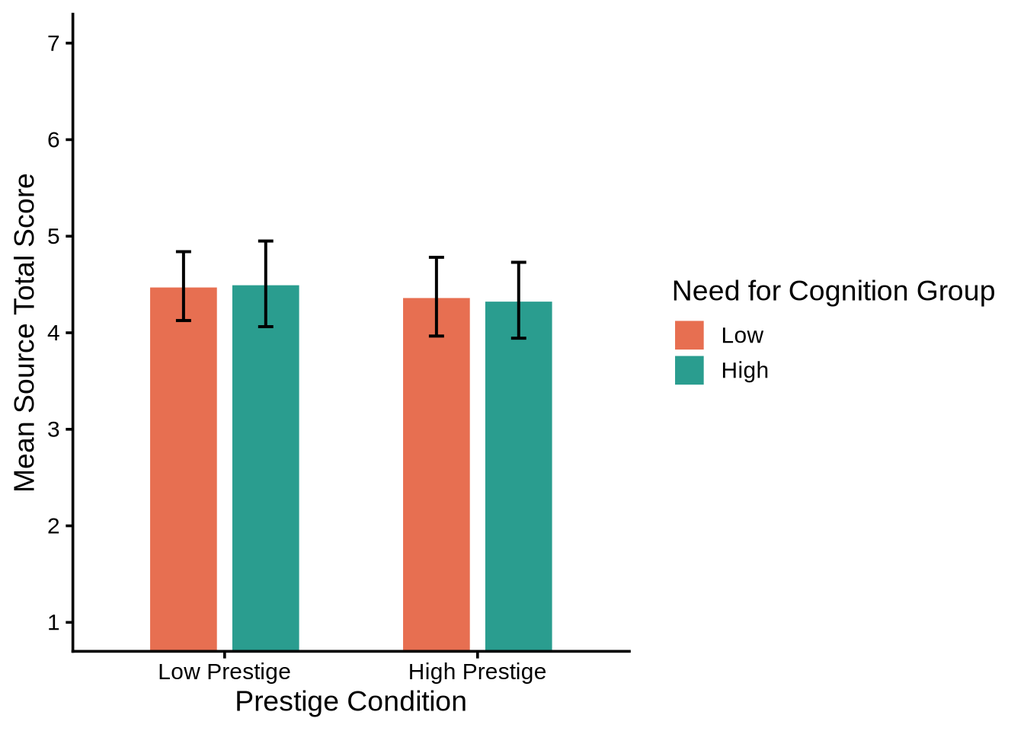

```r
p_source_total_nfc_bar <- ggplot(
  as.data.frame(emmeans(a1_total, ~ condition * nfc_msplit)),
  aes(
    x = condition,
    y = emmean,
    fill = nfc_msplit
  )
) +
  geom_col(
    position = position_dodge(width = 0.65),
    width = 0.55,
    color = "white"
  ) +
  geom_errorbar(
    aes(
      ymin = lower.CL,
      ymax = upper.CL
    ),
    position = position_dodge(width = 0.65),
    width = 0.12,
    linewidth = 0.7
  ) +
  labs(
    x = "Prestige Condition",
    y = "Mean Source Total Score",
    fill = "Need for Cognition Group"
  ) +
  scale_fill_manual(
    values = c(
      "Low" = "#E76F51", # YOU CAN CHANGE THESE HEX VALUES TO MATCH YOUR POSTER!
      "High" = "#2A9D8F"
    )
  ) +
  scale_y_continuous(
    breaks = seq(1, 7, 1)
  ) +
  coord_cartesian(
    ylim = c(1, 7)
  ) +
  theme_classic(
    base_size = 14
  )

p_source_total_nfc_bar
```

This figure shows estimated perceived credibility scores by university prestige and NFC condition. Error bars represent 95% confidence intervals.

### Plot 2: Source Competence x NFC Interaction Plot

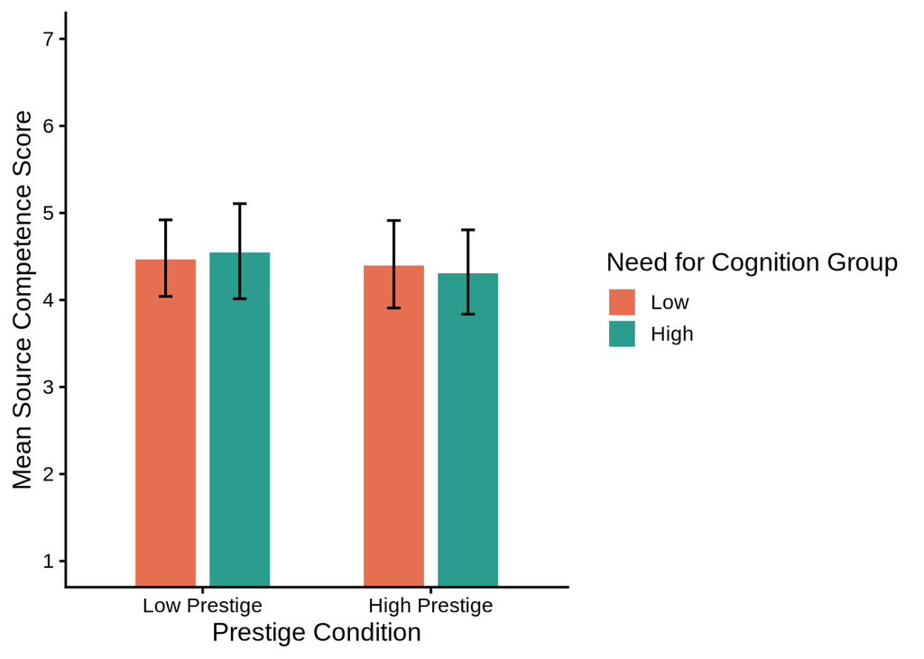

```r
p_source_competence_nfc_bar <- ggplot(
  as.data.frame(emmeans(a2_competence, ~ condition * nfc_msplit)),
  aes(
    x = condition,
    y = emmean,
    fill = nfc_msplit
  )
) +
  geom_col(
    position = position_dodge(width = 0.65),
    width = 0.55,
    color = "white"
  ) +
  geom_errorbar(
    aes(
      ymin = lower.CL,
      ymax = upper.CL
    ),
    position = position_dodge(width = 0.65),
    width = 0.12,
    linewidth = 0.7
  ) +
  labs(
    x = "Prestige Condition",
    y = "Mean Source Competence Score",
    fill = "Need for Cognition Group"
  ) +
  scale_fill_manual(
    values = c(
      "Low" = "#E76F51", # YOU CAN CHANGE THESE HEX VALUES TO MATCH YOUR POSTER!
      "High" = "#2A9D8F"
    )
  ) +
  scale_y_continuous(
    breaks = seq(1, 7, 1)
  ) +
  coord_cartesian(
    ylim = c(1, 7)
  ) +
  theme_classic(
    base_size = 14
  )

p_source_competence_nfc_bar
```

This figure shows estimated scores of **perceived source competence,** **a subscale of overall perceived source credibility**, university prestige, and NFC condition. Error bars represent 95% confidence intervals.

### Plot 3: Source Goodwill × Need for Cognition Interaction Plot

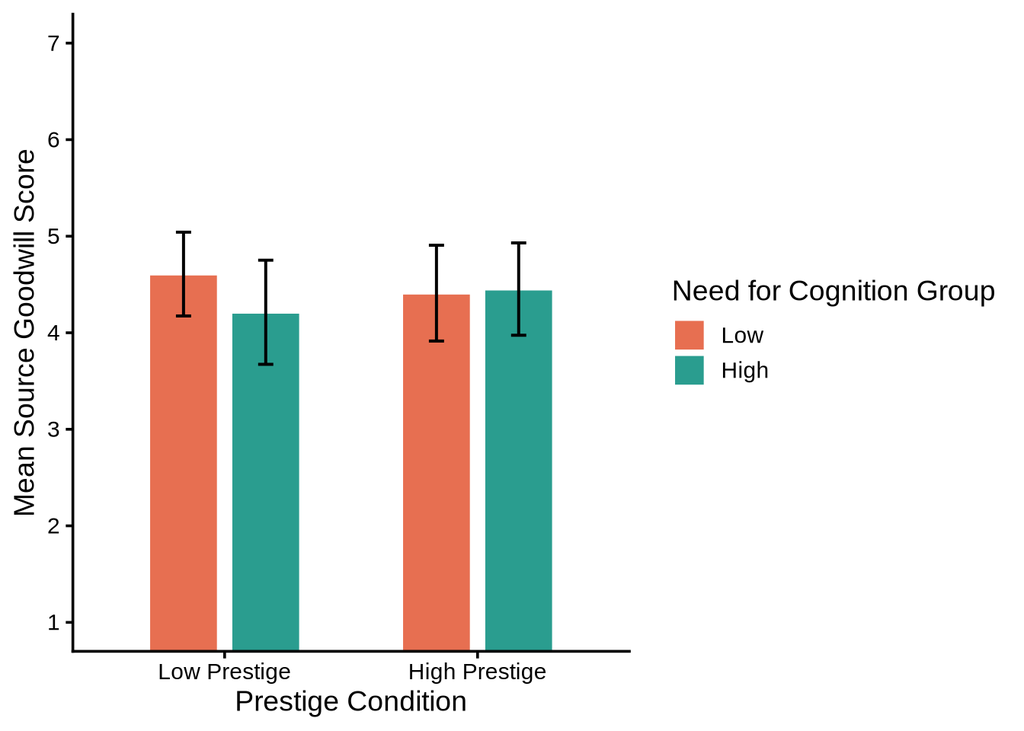

```r
p_source_goodwill_nfc_bar <- ggplot(
  as.data.frame(emmeans(a3_goodwill, ~ condition * nfc_msplit)),
  aes(
    x = condition,
    y = emmean,
    fill = nfc_msplit
  )
) +
  geom_col(
    position = position_dodge(width = 0.65),
    width = 0.55,
    color = "white"
  ) +
  geom_errorbar(
    aes(
      ymin = lower.CL,
      ymax = upper.CL
    ),
    position = position_dodge(width = 0.65),
    width = 0.12,
    linewidth = 0.7
  ) +
  labs(
    x = "Prestige Condition",
    y = "Mean Source Goodwill Score",
    fill = "Need for Cognition Group"
  ) +
  scale_fill_manual(
    values = c(
      "Low" = "#E76F51",
      "High" = "#2A9D8F"
    )
  ) +
  scale_y_continuous(
    breaks = seq(1, 7, 1)
  ) +
  coord_cartesian(
    ylim = c(1, 7)
  ) +
  theme_classic(
    base_size = 14
  )

p_source_goodwill_nfc_bar
```

This figure shows estimated scores of **perceived source goodwill,** **a subscale of overall perceived source credibility**, university prestige, and NFC condition. Error bars represent 95% confidence intervals.

### Plot 4: Source Trustworthiness × Need for Cognition Interaction Plot

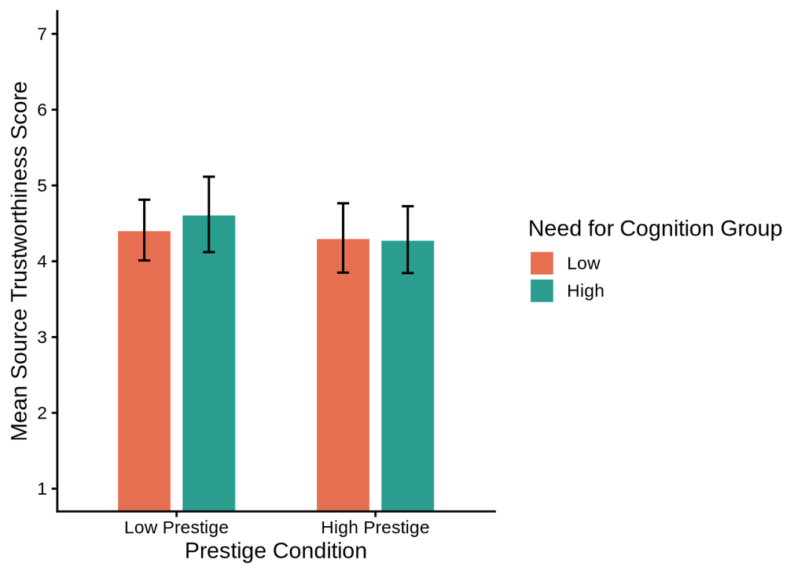

```r
p_source_trustworthiness_nfc_bar <- ggplot(
  as.data.frame(emmeans(a4_trustworthiness, ~ condition * nfc_msplit)),
  aes(
    x = condition,
    y = emmean,
    fill = nfc_msplit
  )
) +
  geom_col(
    position = position_dodge(width = 0.65),
    width = 0.55,
    color = "white"
  ) +
  geom_errorbar(
    aes(
      ymin = lower.CL,
      ymax = upper.CL
    ),
    position = position_dodge(width = 0.65),
    width = 0.12,
    linewidth = 0.7
  ) +
  labs(
    x = "Prestige Condition",
    y = "Mean Source Trustworthiness Score",
    fill = "Need for Cognition Group"
  ) +
  scale_fill_manual(
    values = c(
      "Low" = "#E76F51",
      "High" = "#2A9D8F"
    )
  ) +
  scale_y_continuous(
    breaks = seq(1, 7, 1)
  ) +
  coord_cartesian(
    ylim = c(1, 7)
  ) +
  theme_classic(
    base_size = 14
  )

p_source_trustworthiness_nfc_bar
```

This figure shows estimated scores of **perceived source trustworthiness,** **a subscale of overall perceived source credibility**, university prestige, and NFC condition. Error bars represent 95% confidence intervals.

### Plot 5: Source Total × Trust in Science Interaction Plot

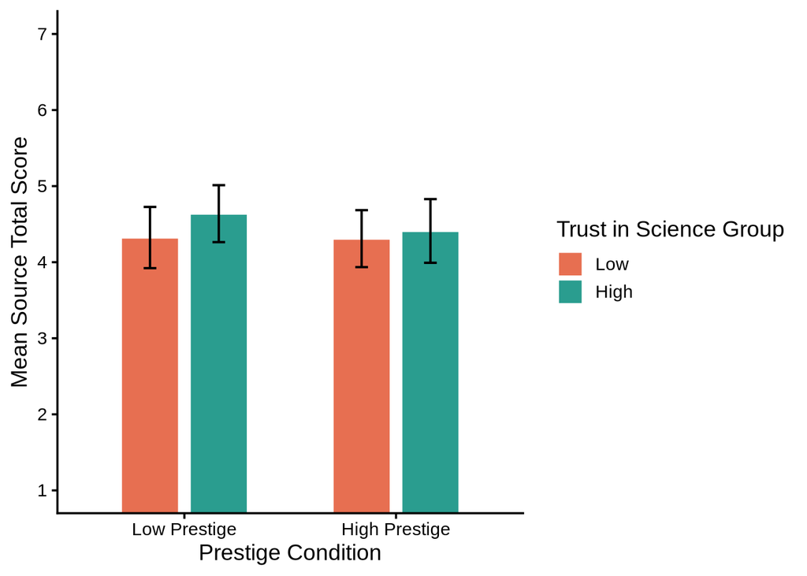

```r
p_source_total_tis_bar <- ggplot(
  as.data.frame(emmeans(a5_total, ~ condition * tis_msplit)),
  aes(
    x = condition,
    y = emmean,
    fill = tis_msplit
  )
) +
  geom_col(
    position = position_dodge(width = 0.65),
    width = 0.55,
    color = "white"
  ) +
  geom_errorbar(
    aes(
      ymin = lower.CL,
      ymax = upper.CL
    ),
    position = position_dodge(width = 0.65),
    width = 0.12,
    linewidth = 0.7
  ) +
  labs(
    x = "Prestige Condition",
    y = "Mean Source Total Score",
    fill = "Trust in Science Group"
  ) +
  scale_fill_manual(
    values = c(
      "Low" = "#E76F51",
      "High" = "#2A9D8F"
    )
  ) +
  scale_y_continuous(
    breaks = seq(1, 7, 1)
  ) +
  coord_cartesian(
    ylim = c(1, 7)
  ) +
  theme_classic(
    base_size = 14
  )

p_source_total_tis_bar
```

This figure shows estimated perceived credibility scores by university prestige and TIS condition. Error bars represent 95% confidence intervals.

### Plot 6: Source Competence × Trust in Science Interaction Plot

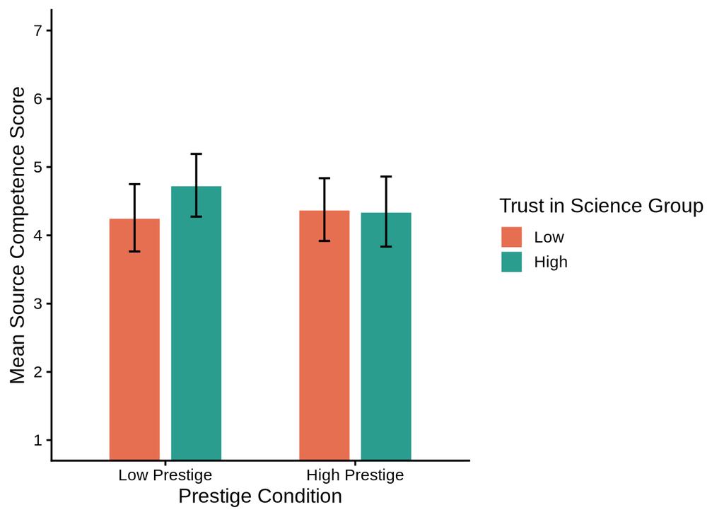

```r
p_source_competence_tis_bar <- ggplot(
  as.data.frame(emmeans(a6_competence, ~ condition * tis_msplit)),
  aes(
    x = condition,
    y = emmean,
    fill = tis_msplit
  )
) +
  geom_col(
    position = position_dodge(width = 0.65),
    width = 0.55,
    color = "white"
  ) +
  geom_errorbar(
    aes(
      ymin = lower.CL,
      ymax = upper.CL
    ),
    position = position_dodge(width = 0.65),
    width = 0.12,
    linewidth = 0.7
  ) +
  labs(
    x = "Prestige Condition",
    y = "Mean Source Competence Score",
    fill = "Trust in Science Group"
  ) +
  scale_fill_manual(
    values = c(
      "Low" = "#E76F51",
      "High" = "#2A9D8F"
    )
  ) +
  scale_y_continuous(
    breaks = seq(1, 7, 1)
  ) +
  coord_cartesian(
    ylim = c(1, 7)
  ) +
  theme_classic(
    base_size = 14
  )

p_source_competence_tis_bar
```

This figure shows estimated scores of **perceived source competence,** **a subscale of overall perceived source credibility**, university prestige, and TIS condition. Error bars represent 95% confidence intervals.

### Plot 7: Source Goodwill × Trust in Science Interaction Plot

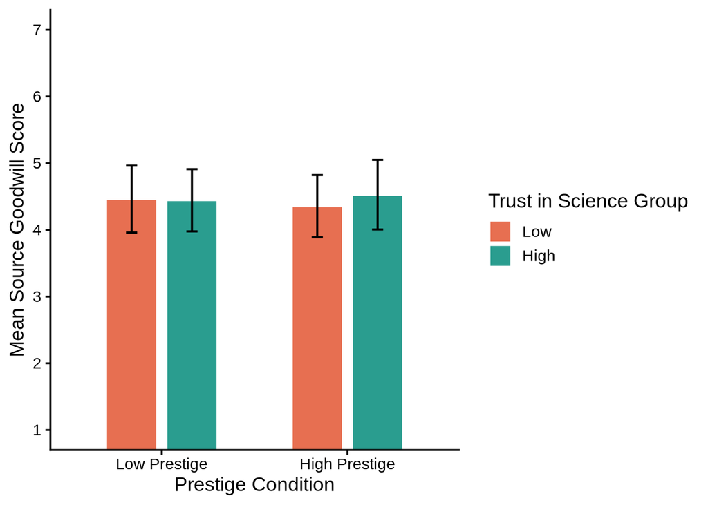

```r
p_source_goodwill_tis_bar <- ggplot(
  as.data.frame(emmeans(a7_goodwill, ~ condition * tis_msplit)),
  aes(
    x = condition,
    y = emmean,
    fill = tis_msplit
  )
) +
  geom_col(
    position = position_dodge(width = 0.65),
    width = 0.55,
    color = "white"
  ) +
  geom_errorbar(
    aes(
      ymin = lower.CL,
      ymax = upper.CL
    ),
    position = position_dodge(width = 0.65),
    width = 0.12,
    linewidth = 0.7
  ) +
  labs(
    x = "Prestige Condition",
    y = "Mean Source Goodwill Score",
    fill = "Trust in Science Group"
  ) +
  scale_fill_manual(
    values = c(
      "Low" = "#E76F51",
      "High" = "#2A9D8F"
    )
  ) +
  scale_y_continuous(
    breaks = seq(1, 7, 1)
  ) +
  coord_cartesian(
    ylim = c(1, 7)
  ) +
  theme_classic(
    base_size = 14
  )

p_source_goodwill_tis_bar
```

This figure shows estimated scores of **perceived source goodwill,** **a subscale of overall perceived source credibility**, university prestige, and TIS condition. Error bars represent 95% confidence intervals.

### Plot 8: Source Trustworthiness × Trust in Science Interaction Plot

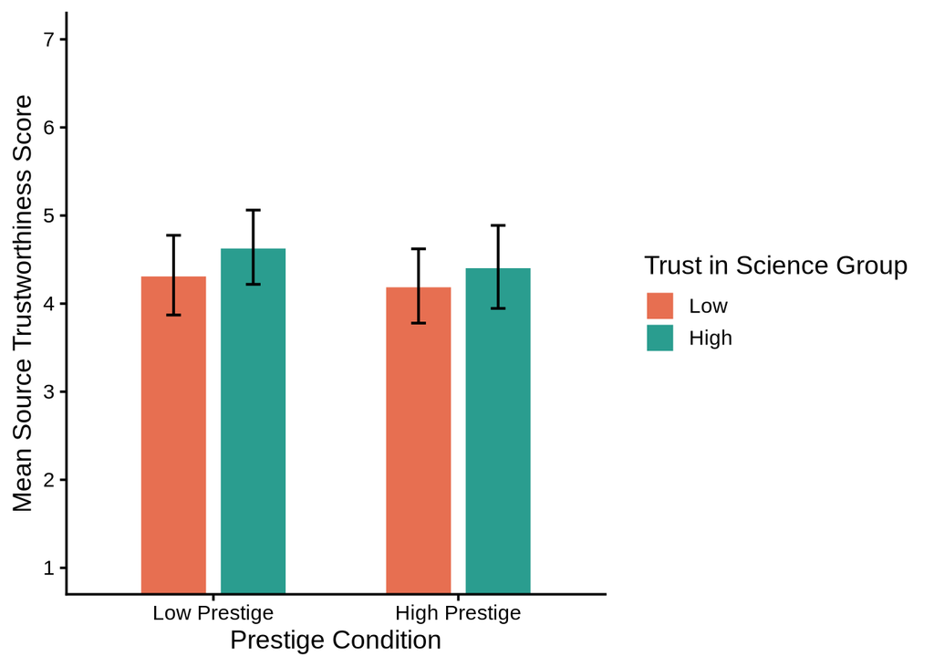

```r
p_source_trustworthiness_tis_bar <- ggplot(
  as.data.frame(emmeans(a8_trustworthiness, ~ condition * tis_msplit)),
  aes(
    x = condition,
    y = emmean,
    fill = tis_msplit
  )
) +
  geom_col(
    position = position_dodge(width = 0.65),
    width = 0.55,
    color = "white"
  ) +
  geom_errorbar(
    aes(
      ymin = lower.CL,
      ymax = upper.CL
    ),
    position = position_dodge(width = 0.65),
    width = 0.12,
    linewidth = 0.7
  ) +
  labs(
    x = "Prestige Condition",
    y = "Mean Source Trustworthiness Score",
    fill = "Trust in Science Group"
  ) +
  scale_fill_manual(
    values = c(
      "Low" = "#E76F51",
      "High" = "#2A9D8F"
    )
  ) +
  scale_y_continuous(
    breaks = seq(1, 7, 1)
  ) +
  coord_cartesian(
    ylim = c(1, 7)
  ) +
  theme_classic(
    base_size = 14
  )

p_source_trustworthiness_tis_bar
```

This figure shows estimated scores of **perceived source trustworthiness,** **a subscale of overall perceived source credibility**, university prestige, and TIS condition. Error bars represent 95% confidence intervals.

### Export Figures

```r
if (!dir.exists("figures")) {
  dir.create("figures")
}

ggsave(
  filename = "figures/source_total_nfc_interaction_plot.svg",
  plot = p_source_total_nfc_bar,
  width = 7,
  height = 5
)

ggsave(
  filename = "figures/source_competence_nfc_interaction_plot.svg",
  plot = p_source_competence_nfc_bar,
  width = 7,
  height = 5
)


ggsave(
  filename = "figures/source_goodwill_nfc_interaction_plot.svg",
  plot = p_source_goodwill_nfc_bar,
  width = 7,
  height = 5
)

ggsave(
  filename = "figures/source_trustworthiness_nfc_interaction_plot.svg",
  plot = p_source_trustworthiness_nfc_bar,
  width = 7,
  height = 5
)

ggsave(
  filename = "figures/source_total_tis_interaction_plot.svg",
  plot = p_source_total_tis_bar,
  width = 7,
  height = 5
)


ggsave(
  filename = "figures/source_competence_tis_interaction_plot.svg",
  plot = p_source_competence_tis_bar,
  width = 7,
  height = 5
)

ggsave(
  filename = "figures/source_goodwill_tis_interaction_plot.svg",
  plot = p_source_goodwill_tis_bar,
  width = 7,
  height = 5
)

ggsave(
  filename = "figures/source_trustworthiness_tis_interaction_plot.svg",
  plot = p_source_trustworthiness_tis_bar,
  width = 7,
  height = 5
)
```

The figures were exported to the `figures/` folder so they can be used in manuscript, poster, or repository materials.

## Results Summary

This section reports the primary analyses used to test whether university prestige level, the need for cognition condition, and their interaction predicted perceived credibility ratings.

It also reports whether university prestige level, the trust in science and scientists level, and their interaction predicted perceived credibility ratings.

Across both ANOVA models, there were no statistically significant main effects or interaction effects. University prestige level was not a statistically significant predictor of perceived credibility ratings. Participants in the high NFC group did not report higher perceived credibility in university research than participants in the low NFC group. Similarly, participants high in trust in science and scientists did not report higher perceived credibility in university research than participants in the low TIS group.

In summary, there was no significant interaction between university prestige and either the NFC level or the TIS level. This indicates that the difference between high and low NFC, and the difference between high and low TIS, did not meaningfully vary across university prestige level.

The estimated means and interaction plots above provide the full model output and visualize the null pattern of results for each outcome.